# Final_Project_SP22

Haoyu Lyu

4/26/2022

### Data Wrangling(1)

```r
# Set the time format
tags <- tags %>%
  mutate(tag_date = as_datetime(timestamp))
ratings <- ratings %>%
  mutate(rating_date = as_datetime(timestamp))
# show head three row
head(ratings,3)
```

```
## # A tibble: 3 x 5
##   userId movieId rating timestamp rating_date
##    <dbl>   <dbl>  <dbl>     <dbl> <dttm>
## 1      1       1      4 964982703 2000-07-30 18:45:03
## 2      1       3      4 964981247 2000-07-30 18:20:47
## 3      1       6      4 964982224 2000-07-30 18:37:04
```

```r
head(tags,3)
```

```
## # A tibble: 3 x 5
##   userId movieId tag              timestamp tag_date
##    <dbl>   <dbl> <chr>                <dbl> <dttm>
## 1      2   60756 funny           1445714994 2015-10-24 19:29:54
## 2      2   60756 Highly quotable 1445714996 2015-10-24 19:29:56
## 3      2   60756 will ferrell    1445714992 2015-10-24 19:29:52
```

### Data wrangling(2)

```r
# Join the data tifether and select 7 variables to show as instruction
join <- ratings %>%
  inner_join(tags,by=c('userId','movieId')) %>%
  inner_join(movies,by='movieId') %>%
  select('userId', 'rating', 'rating_date', 'tag', 'tag_date', 'title', 'genres')
# show head three row
head(join,3)
```

```
## # A tibble: 3 x 7
##   userId rating rating_date         tag         tag_date            title genres
##    <dbl>  <dbl> <dttm>              <chr>       <dttm>              <chr> <chr>
## 1      2      5 2015-10-24 19:29:40 funny       2015-10-24 19:29:54 Step~ Comedy
## 2      2      5 2015-10-24 19:29:40 Highly quo~ 2015-10-24 19:29:56 Step~ Comedy
## 3      2      5 2015-10-24 19:29:40 will ferre~ 2015-10-24 19:29:52 Step~ Comedy
```

Creating a new object called join which shown both rated and tagged movie for further analysis. Put the data together is a way called join.

### Data wrangling(3)

```r
# Tidy the data by instruction
Joinnew <- join %>%
  mutate(release_year = str_extract(title,"\\(\\d{4}\\)$")) %>%
  mutate(title = gsub(pattern = "\\(\\d{4}\\)$", replacement = "", title)) %>%
  mutate(release_year = gsub(pattern = "[()]", replacement = "", release_year))
# show head three row
head(Joinnew,3)
```

```
## # A tibble: 3 x 8
##   userId rating rating_date         tag         tag_date            title genres
##    <dbl>  <dbl> <dttm>              <chr>       <dttm>              <chr> <chr>
## 1      2      5 2015-10-24 19:29:40 funny       2015-10-24 19:29:54 "Ste~ Comedy
## 2      2      5 2015-10-24 19:29:40 Highly quo~ 2015-10-24 19:29:56 "Ste~ Comedy
## 3      2      5 2015-10-24 19:29:40 will ferre~ 2015-10-24 19:29:52 "Ste~ Comedy
## # ... with 1 more variable: release_year <chr>
```

Create a new data object to separate release year from the title.This object can show release year of each movie to give us furture analysis based on the movie year.

### Data visualization(1)

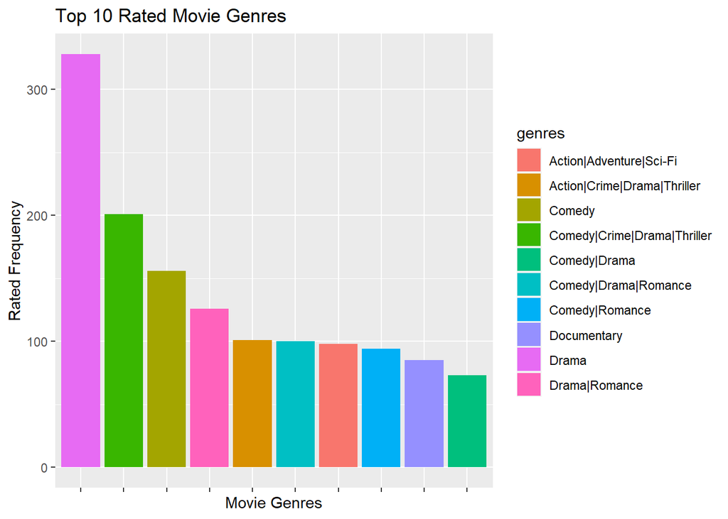

```r
# find the top 10 rated genres
top10genres <- Joinnew %>%
  group_by(genres) %>%
  summarise(count = n()) %>%
  arrange(desc(count))%>%
  head(10)
# using ggplot to show the top 10 rated genres
top10genres %>%
  ggplot(aes(x =reorder(genres,-count), y = count,fill=genres)) +
  geom_bar(stat='identity') +
  ggtitle('Top 10 Rated Movie Genres') +
  xlab('Movie Genres') +
  ylab('Rated Frequency')+
  theme(axis.text.x=element_blank())
```

### Data visualization(2)

Questions: What’s the top 10 rated tag between 2010 to 2020?

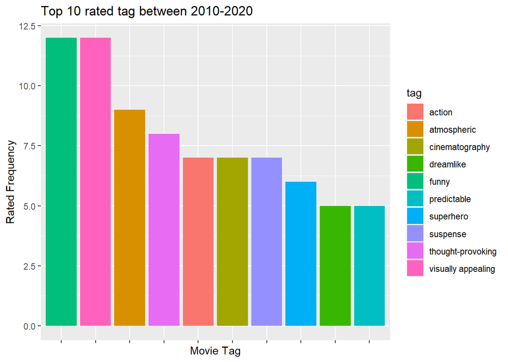

```r
top10Tags <- Joinnew %>%
  group_by(tag) %>%
  filter(between(release_year,2010,2020))%>%
  summarise(count = n()) %>%
  arrange(desc(count)) %>%
  head(10)
top10Tags %>%
  ggplot(aes(x =reorder(tag,-count), y = count,fill=tag)) +
  geom_bar(stat='identity') +
  ggtitle('Top 10 rated tag between 2010-2020') +
  xlab('Movie Tag') +
  ylab('Rated Frequency')+
  theme(axis.text.x=element_blank())
```

interpretive statement: As we all know, the comment tag should be one of the most important elements for a film because when we do marketing for a film, we need to know what should be the movie theme spot and make the decision about adding some elements. As a result, it should be important for us to know what should be the most popular movie tag the audiences like in the last ten years, because data older than ten years is useless for our analysis and decision making. As a result, we can see that over the last ten years, the tags funny movie and visually appealing have risen to the top of the list. The top ten tags are amusing, visually appealing, atmospheric, thought-provoking, action, cinematography, suspense, superhero, dreamlike, and predictable. That can tell us that when we do movie publicity, the tag should be chosen based on the tag.Only the movie with the highest rating will allow the studios to profit. As a result, the rater’s tag is important for movie studios to share and make more movies based on the hottest tag.

### Resources

Select the best way to remove the parentheses:https://statisticsglobe.com/remove-parentheses-character-string-r

### repo address

https://github.com/Howell429/STAT184-SP22-Project/blob/master/FinalProject.Rmd